# Getting started with *landscapeDecoupler*

### Specific decoupling

Users might want to decouple specific scales from a “doucoupled” landscape, for instance, decouple a scale between 250 and 500 m out of a landscape with 1500 m radius total. In the LandscapeDecouple package it is simply done as bellow:

```r
specific.scales <- decouple.specific(multiscales, specific = 2)
#you can also decouple more scales at once, like bellow:
#specific.scales <- decouple.specific(multiscales, c(2,4))
```

for visual inspection, the user can plot the resulted scales at the site 01:

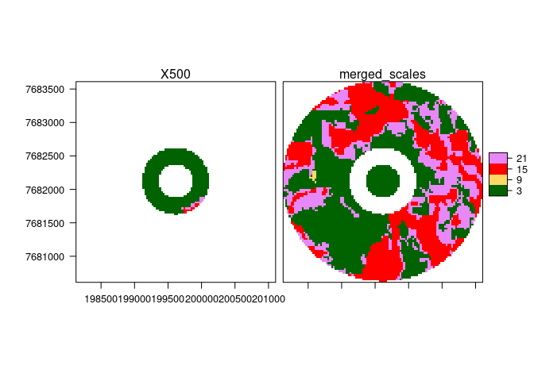

```r
multiplot(specific.scales[[1]], colors = colors$hex)
```

If we extract the metrics from these two raster it will seems like this:

```r
specific.scales.metrics <- extract_metrics(specific.scales)

head(specific.scales.metrics)
```

```
##   site         layer class metric value
## 1  p01          X500     3 counts   667
## 2  p01          X500    15 counts    15
## 3  p01          X500    21 counts    17
## 4  p01 merged_scales     3 counts  3528
## 5  p01 merged_scales     9 counts    12
## 6  p01 merged_scales    15 counts  2409
```

`extract_metrics` is a very fast and convinient way to get some metrics from two different levels: `classes` and `landscape` `counts` = number of cells for a given class `heterog` = the landscape heterogeneity `n_class` = the number of classes in a given landscape `percent` = the proportion of each class in a given landscape

The package also has the possibility to access any metrics in `landscapeMetrics` package. See details in following sections.

## Compatibility with other packages

The output of the `decouple` function is an list of RasterBrick objects, in which each scales is a layer, so users can take advantage of R list functionalities to work with different packages and operations.

### Ploting with other packages

Users can plot `decouple` output with different packages, including `R base` and `tmap`, for instance…

You just need to stack the list or make sure you are pointing to an specific raster item on the list.

**For R base / raster package plot**

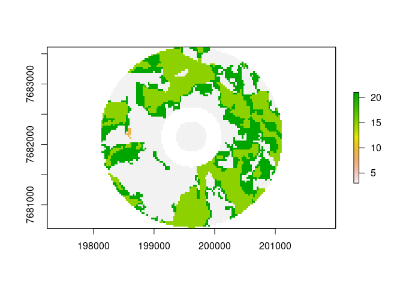

```r
#For R base
plot(specific.scales[[1]][[2]])
```

```r
#or plot(specific.scales$p01$X500)
#or plot(multiscales[[1]][[4]])
#or plot(multiscales$p01$X250)
```

> IMPORTANT if you “id” field is not alphanumeric R will fale in use the `$` operator to access list names. Therefore, you will have to use an syntax like `myobject[1]` to get accesses to your scales in the same order you passed it to the function.

**Plotting with tmap**

`tmap` is a quite popular map plotting package and can be easily used to produce more elaborated plots:

```r
library("tmap")
```

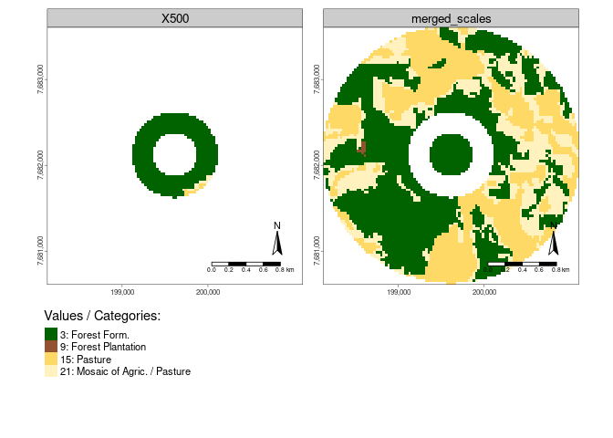

```r
#creating a map for the site p01
map1 <- specific.scales$p01
#checking the categories in this stack
mapcat <- levels(as.factor(getValues(map1)))
#filtering colors that match with stacks
mapcols <- colors[ colors$value %in% mapcat ,]
#now plotting
tm_shape(map1) +
  tm_raster(style = "cat",
            pal = mapcols$hex,
            title = "Values / Categories:",
            labels = paste0(mapcols$value, ": ", mapcols$name)) +
  tm_compass() +
  tm_scale_bar() +
  tm_grid(n.y=3, n.x=3, lines = FALSE, labels.rot = c(0, 90)) +
  tm_layout(legend.outside = T,
            legend.outside.position = "bottom")
```

### Calculating Metrics

Once the user has defined the desired level of comparison and extract his landscape, one might want to proceed with more complex analysis. Other packages as `LandscapeMetrics` might be used to calculate landscape properties.

the `landscapeDecoupler` has an wrapper for the main `LandscapeMetrics` function, the `calculate_lsm`. You can call calculations from a desired metric implemented in `landscapeMetrics` as follow:

```r
#creating an object to receive the data frame
metrics.from.lsm <- calc_lsm(multiscales, level="class", metric=c("ai","ca"))
#printing the head of the data frame
head(metrics.from.lsm)
```

```
## # A tibble: 6 × 7
##   site  layer level class id    metric value
##   <fct> <fct> <fct> <fct> <fct> <fct>  <dbl>
## 1 p01   X250  class 3     <NA>  ai     99.3
## 2 p01   X250  class 3     <NA>  ca     20.0
## 3 p01   X500  class 3     <NA>  ai     95.9
## 4 p01   X500  class 3     <NA>  ca     55.8
## 5 p01   X500  class 15    <NA>  ai     68.2
## 6 p01   X500  class 15    <NA>  ca      1.25
```

As you can see, it is quite easy to access any metrics from landscapeMetrics using `calc_lsm`. You can list available metrics with `list_lsm()`.

#### Using `landscapeMetrics` functions

Although it is not so streightforward as `calc_lsm`, users can also provide the output from the `LandscapeDecoupled` as input into functions from `landscapeMetrics` as follow:

```r
library("landscapemetrics")
area <- calculate_lsm(specific.scales$p01, level = "class", metric = "area")
#Just to show you who are layers 1 and 2 for the landscapeMetrics
paste0("layer", c(1:2),": ", names(specific.scales$p01))
```

```
## [1] "layer1: X500"          "layer2: merged_scales"
```

```r
area[area$metric=="area_mn",  ]
```

```
## # A tibble: 7 × 6
##   layer level class    id metric   value
##   <int> <chr> <int> <int> <chr>    <dbl>
## 1     1 class     3    NA area_mn 55.8
## 2     1 class    15    NA area_mn  1.25
## 3     1 class    21    NA area_mn  0.711
## 4     2 class     3    NA area_mn 21.1
## 5     2 class     9    NA area_mn  1.00
## 6     2 class    15    NA area_mn 11.2
## 7     2 class    21    NA area_mn  4.30
```

```r
#You can also do like this:
#landscapes <- stack(specific.scales[[1]])
#area<-calculate_lsm(landscape, level = "class", metric = "area")
#area
```

`landscapeMetrics` can read the layers in raster contained into `specific.scales[[1]]` index or `specific.scales$p01`. Therefore, the first layer represents the X500 and the seccond layer is the merging of X250, X1000, and X1500.

To walk through our sites we only have to change the index in the list of raster objects (`multsicales` or `specific.scales`). To grab the data from site 2 you can do like this:

`specific.scales[[2]]`

or

`specific.scales$p02`

> REMEMBER: The `$` operator only works when lists have alphanumeric names. Otherwise the `[]` operators will be needed.

you can also do all sites at once like this:

```r
lsmetrics_area <- lapply(specific.scales, calculate_lsm, "class", "area" )
head(lsmetrics_area$p01)
```

```
## # A tibble: 6 × 6
##   layer level class    id metric    value
##   <int> <chr> <int> <int> <chr>     <dbl>
## 1     1 class     3    NA area_cv  NA
## 2     1 class    15    NA area_cv  NA
## 3     1 class    21    NA area_cv 125.
## 4     1 class     3    NA area_mn  55.8
## 5     1 class    15    NA area_mn   1.25
## 6     1 class    21    NA area_mn   0.711
```

```r
#or head(lsmetrics_area$p02) #and so on...
```

You can always change `"class"` by any other level or `"area"` by one of the metrics in landscapemetrics.

## So, now what?

Here you go with basics. Decoupled multiscale approach has a huge potential to lightening several ecological aspects. Now, you can grab your data and have fun!

I hope you find it helpful and useful, but if you end up on any crash or may have a bad time trying to run this code, please fell free to mail me.

## References

Some published papers about using similar approaches:

**Bee responses to landscape composition on coupled and decoupled multiscale approaches**  
*Lazaro Carneiro, Milton Cezar Ribeiro, Willian Moura de Aguiar, Camila de Fátima Priante, Wilson Frantine-Silva, Maria Cristina Gaglianone*  
[Preprint](https://www.researchsquare.com/article/rs-750143/v1)

**The Interplay Between Thematic Resolution, Forest Cover, and Heterogeneity for Explaining Euglossini Bees Community in an Agricultural Landscape**  
*Lázaro da Silva Carneiro, Willian Moura de Aguiar, Camila de Fátima Priante, Milton Cezar Ribeiro, Wilson Frantine-Silva and Maria Cristina Gaglianone*  
https://www.frontiersin.org/articles/10.3389/fevo.2021.628319/full

Dr. Wilson Frantine-Silva  
wilsonfrantine@gmail.com  
Universidade Estadual do Norte Fluminense, Campos dos Goytacazes, RJ - BR LCA, PPGERN, EcoExperimental.  
Laboratório de Ecologia de Abelhas e Polinização.